# Project: Investigate TMDb Movie Database by Marc Nguyen

- Introduction
- Data Wrangling
- Exploratory Data Analysis
- Conclusions

## Introduction

> In this report, I will be investigating the TMDb Movie Database with various information on a variety of movies from 1960 to 2015. The database includes information on movie tiltes, cast, budget, popularity, and revenues.

> With the movie database, I will be investigating two questions:  
> First, I will be looking at what genre is the most popular for each year.  
> Secondly, I will be exploring what kinds of properties are associated with movies that have high revenues?

```python
# Import data
import pandas as pd
import matplotlib.pyplot as plt
% matplotlib inline

df = pd.read_csv('tmdb-movies.csv')
df.head()
```

|  | id | imdb_id | popularity | budget | revenue | original_title | cast | homepage | director | tagline | ... | overview | runtime | genres | production_companies | release_date | vote_count | vote_average | release_year | budget_adj | revenue_adj |
| --- | --- | --- | --- | --- | --- | --- | --- | --- | --- | --- | --- | --- | --- | --- | --- | --- | --- | --- | --- | --- | --- |
| 0 | 135397 | tt0369610 | 32.985763 | 150000000 | 1513528810 | Jurassic World | Chris Pratt\|Bryce Dallas Howard\|Irrfan Khan\|Vi... | http://www.jurassicworld.com/ | Colin Trevorrow | The park is open. | ... | Twenty-two years after the events of Jurassic ... | 124 | Action\|Adventure\|Science Fiction\|Thriller | Universal Studios\|Amblin Entertainment\|Legenda... | 6/9/15 | 5562 | 6.5 | 2015 | 1.379999e+08 | 1.392446e+09 |
| 1 | 76341 | tt1392190 | 28.419936 | 150000000 | 378436354 | Mad Max: Fury Road | Tom Hardy\|Charlize Theron\|Hugh Keays-Byrne\|Nic... | http://www.madmaxmovie.com/ | George Miller | What a Lovely Day. | ... | An apocalyptic story set in the furthest reach... | 120 | Action\|Adventure\|Science Fiction\|Thriller | Village Roadshow Pictures\|Kennedy Miller Produ... | 5/13/15 | 6185 | 7.1 | 2015 | 1.379999e+08 | 3.481613e+08 |
| 2 | 262500 | tt2908446 | 13.112507 | 110000000 | 295238201 | Insurgent | Shailene Woodley\|Theo James\|Kate Winslet\|Ansel... | http://www.thedivergentseries.movie/#insurgent | Robert Schwentke | One Choice Can Destroy You | ... | Beatrice Prior must confront her inner demons ... | 119 | Adventure\|Science Fiction\|Thriller | Summit Entertainment\|Mandeville Films\|Red Wago... | 3/18/15 | 2480 | 6.3 | 2015 | 1.012000e+08 | 2.716190e+08 |
| 3 | 140607 | tt2488496 | 11.173104 | 200000000 | 2068178225 | Star Wars: The Force Awakens | Harrison Ford\|Mark Hamill\|Carrie Fisher\|Adam D... | http://www.starwars.com/films/star-wars-episod... | J.J. Abrams | Every generation has a story. | ... | Thirty years after defeating the Galactic Empi... | 136 | Action\|Adventure\|Science Fiction\|Fantasy | Lucasfilm\|Truenorth Productions\|Bad Robot | 12/15/15 | 5292 | 7.5 | 2015 | 1.839999e+08 | 1.902723e+09 |
| 4 | 168259 | tt2820852 | 9.335014 | 190000000 | 1506249360 | Furious 7 | Vin Diesel\|Paul Walker\|Jason Statham\|Michelle ... | http://www.furious7.com/ | James Wan | Vengeance Hits Home | ... | Deckard Shaw seeks revenge against Dominic Tor... | 137 | Action\|Crime\|Thriller | Universal Pictures\|Original Film\|Media Rights ... | 4/1/15 | 2947 | 7.3 | 2015 | 1.747999e+08 | 1.385749e+09 |

5 rows × 21 columns

## General Properties

>

> Looking a various information on the database before data wrangling

```python
# Summary of dataframe
df.info()
```

```
<class 'pandas.core.frame.DataFrame'>
RangeIndex: 10866 entries, 0 to 10865
Data columns (total 21 columns):
id                      10866 non-null int64
imdb_id                 10856 non-null object
popularity              10866 non-null float64
budget                  10866 non-null int64
revenue                 10866 non-null int64
original_title          10866 non-null object
cast                    10790 non-null object
homepage                2936 non-null object
director                10822 non-null object
tagline                 8042 non-null object
keywords                9373 non-null object
overview                10862 non-null object
runtime                 10866 non-null int64
genres                  10843 non-null object
production_companies    9836 non-null object
release_date            10866 non-null object
vote_count              10866 non-null int64
vote_average            10866 non-null float64
release_year            10866 non-null int64
budget_adj              10866 non-null float64
revenue_adj             10866 non-null float64
dtypes: float64(4), int64(6), object(11)
memory usage: 1.7+ MB
```

```python
# Check column names for white space and naming convention
df.columns
```

```
Index(['id', 'imdb_id', 'popularity', 'budget', 'revenue', 'original_title',
       'cast', 'homepage', 'director', 'tagline', 'keywords', 'overview',
       'runtime', 'genres', 'production_companies', 'release_date',
       'vote_count', 'vote_average', 'release_year', 'budget_adj',
       'revenue_adj'],
      dtype='object')
```

```python
# get a general analysis of the data
df.describe()
```

|  | id | popularity | budget | revenue | runtime | vote_count | vote_average | release_year | budget_adj | revenue_adj |
| --- | --- | --- | --- | --- | --- | --- | --- | --- | --- | --- |
| count | 10866.000000 | 10866.000000 | 1.086600e+04 | 1.086600e+04 | 10866.000000 | 10866.000000 | 10866.000000 | 10866.000000 | 1.086600e+04 | 1.086600e+04 |
| mean | 66064.177434 | 0.646441 | 1.462570e+07 | 3.982332e+07 | 102.070863 | 217.389748 | 5.974922 | 2001.322658 | 1.755104e+07 | 5.136436e+07 |
| std | 92130.136561 | 1.000185 | 3.091321e+07 | 1.170035e+08 | 31.381405 | 575.619058 | 0.935142 | 12.812941 | 3.430616e+07 | 1.446325e+08 |
| min | 5.000000 | 0.000065 | 0.000000e+00 | 0.000000e+00 | 0.000000 | 10.000000 | 1.500000 | 1960.000000 | 0.000000e+00 | 0.000000e+00 |
| 25% | 10596.250000 | 0.207583 | 0.000000e+00 | 0.000000e+00 | 90.000000 | 17.000000 | 5.400000 | 1995.000000 | 0.000000e+00 | 0.000000e+00 |
| 50% | 20669.000000 | 0.383856 | 0.000000e+00 | 0.000000e+00 | 99.000000 | 38.000000 | 6.000000 | 2006.000000 | 0.000000e+00 | 0.000000e+00 |
| 75% | 75610.000000 | 0.713817 | 1.500000e+07 | 2.400000e+07 | 111.000000 | 145.750000 | 6.600000 | 2011.000000 | 2.085325e+07 | 3.369710e+07 |
| max | 417859.000000 | 32.985763 | 4.250000e+08 | 2.781506e+09 | 900.000000 | 9767.000000 | 9.200000 | 2015.000000 | 4.250000e+08 | 2.827124e+09 |

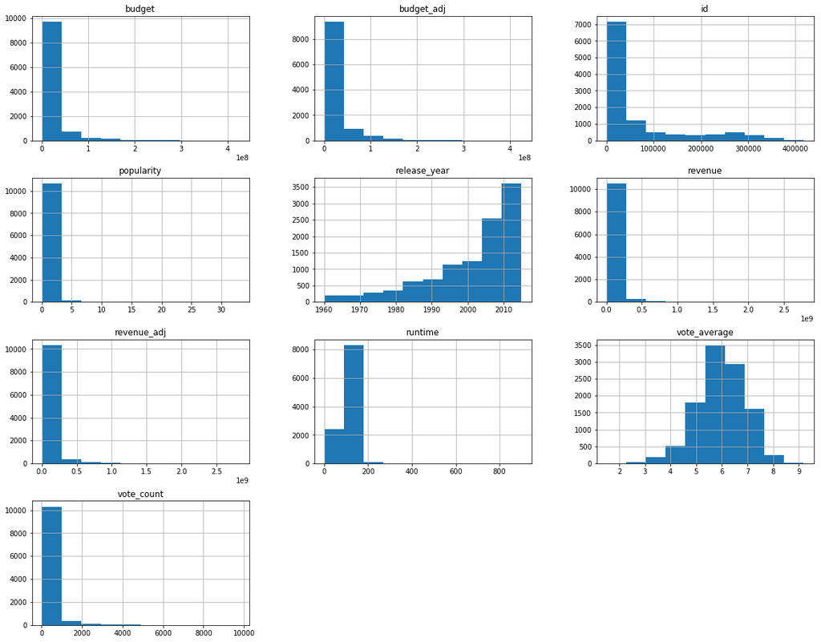

```python
# Quick visual of the data
df.hist(figsize=(20,16));
```

## Data Wrangling

### Note:

> 1. All the data type looks correct. No change required.
> 2. All column names looks good. No change required.

## Clean duplicate datas

```python
# check number of duplicates
df.duplicated().sum()
```

```
1
```

```python
# Check for duplicated entries
df[df.duplicated(keep=False)]
```

|  | id | imdb_id | popularity | budget | revenue | original_title | cast | homepage | director | tagline | ... | overview | runtime | genres | production_companies | release_date | vote_count | vote_average | release_year | budget_adj | revenue_adj |
| --- | --- | --- | --- | --- | --- | --- | --- | --- | --- | --- | --- | --- | --- | --- | --- | --- | --- | --- | --- | --- | --- |
| 2089 | 42194 | tt0411951 | 0.59643 | 30000000 | 967000 | TEKKEN | Jon Foo\|Kelly Overton\|Cary-Hiroyuki Tagawa\|Ian... | NaN | Dwight H. Little | Survival is no game | ... | In the year of 2039, after World Wars destroy ... | 92 | Crime\|Drama\|Action\|Thriller\|Science Fiction | Namco\|Light Song Films | 3/20/10 | 110 | 5.0 | 2010 | 30000000.0 | 967000.0 |
| 2090 | 42194 | tt0411951 | 0.59643 | 30000000 | 967000 | TEKKEN | Jon Foo\|Kelly Overton\|Cary-Hiroyuki Tagawa\|Ian... | NaN | Dwight H. Little | Survival is no game | ... | In the year of 2039, after World Wars destroy ... | 92 | Crime\|Drama\|Action\|Thriller\|Science Fiction | Namco\|Light Song Films | 3/20/10 | 110 | 5.0 | 2010 | 30000000.0 | 967000.0 |

2 rows × 21 columns

```python
# Drop duplicated rows and verify it has been deleted
df.drop_duplicates(inplace=True)
df.duplicated().sum()
```

```
0
```

### Note:

> Found two identical data rows. Only one is needed, so the duplicate was deleted.

### Investigate Missing data

```python
# Check for missing data
df.isnull().sum()
```

```
id                         0
imdb_id                   10
popularity                 0
budget                     0
revenue                    0
original_title             0
cast                      76
homepage                7929
director                  44
tagline                 2824
keywords                1493
overview                   4
runtime                    0
genres                    23
production_companies    1030
release_date               0
vote_count                 0
vote_average               0
release_year               0
budget_adj                 0
revenue_adj                0
dtype: int64
```

```python
# Drop Null data in genres columns since there 23 rows missing data
# Since we couldn't perform contain search with Null data
df.dropna(axis=0, subset=['genres'], inplace=True)
```

### Note:

> Decided to drop all 23 rows with missing data in the genres since it is not wise to assume the genres or use the median and it will minimally impact the data analysis.

```python
# Investigate null data in Director column
df[df.director.isnull()]
```

|  | id | imdb_id | popularity | budget | revenue | original_title | cast | homepage | director | tagline | ... | overview | runtime | genres | production_companies | release_date | vote_count | vote_average | release_year | budget_adj | revenue_adj |
| --- | --- | --- | --- | --- | --- | --- | --- | --- | --- | --- | --- | --- | --- | --- | --- | --- | --- | --- | --- | --- | --- |
| 532 | 320996 | tt4073952 | 0.126594 | 0 | 0 | Iliza Shlesinger: Freezing Hot | Iliza Shlesinger | http://www.iliza.com/freezing-hot.html | NaN | NaN | ... | Smart and brazen comedian Iliza Shlesinger sha... | 71 | Comedy | New Wave Entertainment | 1/23/15 | 14 | 6.6 | 2015 | 0.000000e+00 | 0.000000e+00 |
| 548 | 355131 | NaN | 0.108072 | 0 | 0 | Sense8: Creating the World | Tuppence Middleton\|Bae Doona \|Brian J. Smith\|A... | NaN | NaN | NaN | ... | NaN | 25 | Documentary\|Science Fiction | Netflix | 8/10/15 | 12 | 7.5 | 2015 | 0.000000e+00 | 0.000000e+00 |
| 556 | 321160 | tt3908634 | 0.100910 | 0 | 0 | With This Ring | Regina Hall\|Jill Scott\|Eve\|Brooklyn Sudano\|Dei... | http://www.mylifetime.com/movies/with-this-ring | NaN | NaN | ... | After attending their friend Elise's (Sudano) ... | 105 | Comedy\|Romance | Lifetime Television\|Sony Pictures Television | 1/24/15 | 14 | 6.5 | 2015 | 0.000000e+00 | 0.000000e+00 |
| 1032 | 259910 | tt3591568 | 0.291253 | 0 | 0 | Marvel Studios: Assembling a Universe | Robert Downey Jr.\|Chris Hemsworth\|Chris Evans\|... | NaN | NaN | - | ... | A look at the story behind Marvel Studios and ... | 43 | TV Movie\|Documentary | Marvel Studios\|ABC Studios | 3/18/14 | 32 | 6.3 | 2014 | 0.000000e+00 | 0.000000e+00 |
| 1054 | 253675 | tt3711030 | 0.269468 | 0 | 0 | Unlocking Sherlock | Benedict Cumberbatch\|Martin Freeman\|Steven Mof... | NaN | NaN | NaN | ... | Explore how writers Steven Moffat and Mark Gat... | 60 | TV Movie\|Documentary | NaN | 1/19/14 | 11 | 7.2 | 2014 | 0.000000e+00 | 0.000000e+00 |
| 1203 | 256561 | tt3203290 | 0.119891 | 150000 | 0 | Free to Play | Benedict Lim\|Danil Ishutin\|Clinton Loomis | http://www.freetoplaythemovie.com | NaN | One game will change their lives. | ... | Follow three professional video game players a... | 75 | Documentary | Valve | 3/19/14 | 40 | 7.0 | 2014 | 1.381637e+05 | 0.000000e+00 |
| 1241 | 296370 | tt3024964 | 0.135376 | 0 | 0 | Dance-Off | Kathryn McCormick\|Shane Harper\|Finola Hughes\|C... | NaN | NaN | NaN | ... | DANCE-OFF is a tongue-in-cheek family comedy s... | 0 | Romance\|Music\|Comedy | NaN | 1/1/14 | 18 | 5.7 | 2014 | 0.000000e+00 | 0.000000e+00 |
| 1288 | 301235 | tt4217172 | 0.038364 | 0 | 0 | Top Gear: The Perfect Road Trip 2 | Jeremy Clarkson\|Richard Hammond | NaN | NaN | NaN | ... | In 2013 Jeremy Clarkson and Richard Hammond em... | 94 | Documentary | 2 Entertain Video | 11/17/14 | 12 | 6.8 | 2014 | 0.000000e+00 | 0.000000e+00 |
| 1852 | 133365 | tt1127205 | 0.256703 | 0 | 0 | The Diary of Anne Frank | Ellie Kendrick\|Kate Ashfield\|Geoff Breton\|Feli... | NaN | NaN | NaN | ... | Called the most accurate adaptation of Anne Fr... | 100 | Drama | Darlow Smithson Productions\|British Broadcasti... | 1/9/09 | 19 | 7.5 | 2009 | 0.000000e+00 | 0.000000e+00 |
| 1872 | 26379 | tt1532957 | 0.091395 | 3250000 | 0 | Paa | Amitabh Bachchan\|Abhishek Bachchan\|Vidya Balan... | http://www.paathefilm.com/ | NaN | NaN | ... | He suffers from a progeria like syndrome. Ment... | 133 | Drama\|Family\|Foreign | A B Corp | 12/4/09 | 11 | 6.1 | 2009 | 3.303301e+06 | 0.000000e+00 |
| 1895 | 281979 | tt1413314 | 0.056777 | 0 | 0 | Doctor Who: The Waters of Mars | David Tennant | NaN | NaN | NaN | ... | The Doctor joins forces with his oldest compan... | 62 | Science Fiction\|Adventure\|Family | BBC Wales | 12/19/09 | 25 | 8.0 | 2009 | 0.000000e+00 | 0.000000e+00 |
| 2221 | 48832 | tt1707823 | 0.281852 | 0 | 0 | Scott Pilgrim vs. the Animation | Michael Cera\|Alison Pill\|Georgette Perna\|Mae W... | NaN | NaN | Read the Comic. Watch the Movie. See the Anima... | ... | Scott Pilgrim vs. The Animation is an animated... | 4 | TV Movie\|Animation\|Adventure | Titmouse | 8/10/10 | 19 | 7.7 | 2010 | 0.000000e+00 | 0.000000e+00 |
| 2286 | 47911 | tt1747960 | 0.207234 | 0 | 0 | Bo Burnham: Words, Words, Words | Bo Burnham | NaN | NaN | NaN | ... | Bo Burnham is back with a new one-man show ful... | 63 | Comedy | NaN | 10/19/10 | 13 | 6.5 | 2010 | 0.000000e+00 | 0.000000e+00 |
| 2290 | 51823 | tt1663193 | 0.203502 | 0 | 0 | Across the Line: The Exodus of Charlie Wright | Aidan Quinn\|Andy García\|Mario Van Peebles\|Dan... | NaN | NaN | Redemption has its price. | ... | The story centers on Charlie, a Los Angeles bi... | 94 | Drama\|Action\|Thriller\|Crime | NaN | 12/28/10 | 11 | 6.0 | 2010 | 0.000000e+00 | 0.000000e+00 |
| 2315 | 48373 | tt1274296 | 0.171615 | 0 | 0 | Listen to Your Heart | Alexia Rasmussen\|Kent Moran\|Cybill Shepherd\|Sh... | http://www.listentoyourheartfilm.com/ | NaN | One song can change your life. | ... | Danny Foster doesn't have much: an apartment a... | 0 | Drama\|Music\|Romance | NaN | 8/14/10 | 29 | 7.3 | 2010 | 0.000000e+00 | 0.000000e+00 |
| 2318 | 34134 | tt1610301 | 0.170408 | 0 | 0 | Barbie in A Mermaid Tale | Kelly Sheridan\|Kathleen Barr\|Nakia Burrise\|Gar... | http://www.barbie.com/mermaid-tale/ | NaN | NaN | ... | Barbie stars as Merliah, a surfing champion fr... | 75 | Animation\|Family\|Fantasy | NaN | 1/26/10 | 35 | 6.3 | 2010 | 0.000000e+00 | 0.000000e+00 |
| 2397 | 241829 | tt1805454 | 0.033048 | 0 | 0 | The Making of The Walking Dead | NaN | NaN | NaN | NaN | ... | The Making of the TV Series The Walking Dead | 30 | Documentary | NaN | 7/31/10 | 42 | 8.4 | 2010 | 0.000000e+00 | 0.000000e+00 |
| 2401 | 45644 | NaN | 0.067753 | 0 | 0 | Opeth: In Live Concert At The Royal Albert Hall | Mikael Åkerfeldt\|Martin "Axe" Axenrot\|Martin ... | http://www.opeth.com | NaN | The Loyal Disharmonic Orchestra, Conducted By ... | ... | As part of the ongoing celebration of their 20... | 163 | Music | NaN | 9/21/10 | 10 | 8.6 | 2010 | 0.000000e+00 | 0.000000e+00 |
| 2403 | 72013 | tt1587157 | 0.067620 | 0 | 0 | Yu-Gi-Oh! 3D: Bonds Beyond Time | Greg Abbey\|Dan Green\|Matthew Charles\|Sean Sche... | NaN | NaN | NaN | ... | After falling through a time-slip, Yusei Fudo ... | 60 | Animation\|Fantasy | NaN | 1/23/10 | 10 | 6.0 | 2010 | 0.000000e+00 | 0.000000e+00 |
| 3171 | 17171 | tt1201984 | 0.019819 | 0 | 0 | The Assassination of Jesse James: Death Of An ... | Ted Levine\|Casey Affleck\|Brad Pitt\|Mary-Louise... | NaN | NaN | NaN | ... | Explores the true story of the notorious Jesse... | 32 | Documentary | New Wave Entertainment | 1/1/08 | 20 | 6.8 | 2008 | 0.000000e+00 | 0.000000e+00 |
| 3224 | 20313 | tt1270491 | 0.224721 | 0 | 0 | John Mayer: Where the Light Is Live in Los Ang... | John Mayer\|Steve Jordan\|Pino Palladino\|David R... | NaN | NaN | NaN | ... | Where The Light Is: John Mayer Live in Los Ang... | 164 | Music | NaN | 7/1/08 | 16 | 8.5 | 2008 | 0.000000e+00 | 0.000000e+00 |
| 3276 | 15467 | tt1105733 | 0.147657 | 4180000 | 11000000 | Kismat Konnection | Shahid Kapoor\|Vidya Balan\|Juhi Chawla\|Om Puri\|... | http://www.kismatkonnection.tips.in/ | NaN | NaN | ... | This is a story about an architect Raj Malhotr... | 153 | Drama\|Comedy\|Romance\|Foreign | Tips Industries | 7/18/08 | 11 | 5.8 | 2008 | 4.233448e+06 | 1.114065e+07 |
| 3285 | 36131 | tt1286750 | 0.136883 | 0 | 0 | Tropic Thunder: Rain of Madness | Justin Theroux\|Jack Black\|Steve Coogan\|Robert ... | NaN | NaN | Before the thunder... comes the madness. | ... | A behind-the-scenes mockumentary of Tropic Thu... | 30 | Action\|Comedy | NaN | 8/26/08 | 12 | 6.9 | 2008 | 0.000000e+00 | 0.000000e+00 |
| 3357 | 32836 | tt1254947 | 0.042517 | 0 | 0 | Bill Burr: Why Do I Do This? | Bill Burr | NaN | NaN | NaN | ... | One of America's fastest-rising comedians, Bil... | 55 | Comedy | NaN | 9/23/08 | 10 | 8.0 | 2008 | 0.000000e+00 | 0.000000e+00 |
| 3365 | 22258 | tt1321823 | 0.002475 | 0 | 0 | Foo Fighters: Live at Wembley Stadium | Dave Grohl\|Nate Mendel\|Chris Shiflett\|Pat Smea... | NaN | NaN | NaN | ... | Foo Fighters captured over their two sold-out ... | 120 | Music | NaN | 8/25/08 | 10 | 8.4 | 2008 | 0.000000e+00 | 0.000000e+00 |
| 3369 | 77974 | tt2014400 | 0.001682 | 0 | 0 | Wizards On Deck With Hannah Montana | NaN | NaN | NaN | NaN | ... | Three Disney Channel shows come together in "W... | 68 | Family | NaN | 2/11/08 | 14 | 6.1 | 2008 | 0.000000e+00 | 0.000000e+00 |
| 3910 | 79976 | tt2096615 | 0.002006 | 0 | 0 | Steve Jobs: One Last Thing | NaN | NaN | NaN | NaN | ... | Through interviews with colleagues and others ... | 60 | Documentary | NaN | 11/2/11 | 11 | 6.6 | 2011 | 0.000000e+00 | 0.000000e+00 |
| 4679 | 91342 | tt2197823 | 0.421746 | 0 | 0 | Barbie in A Mermaid Tale 2 | Nakia Burrise\|Gary Chalk | NaN | NaN | NaN | ... | Surf's up for Barbie as she returns as Merliah... | 74 | Animation\|Family | Mattel | 2/23/12 | 22 | 6.0 | 2012 | 0.000000e+00 | 0.000000e+00 |
| 4872 | 269177 | NaN | 0.090552 | 0 | 0 | Party Bercy | Florence Foresti | NaN | NaN | NaN | ... | Florence Foresti is offered Bercy tribute to a... | 120 | Comedy | TF1 Vidéo | 9/23/12 | 15 | 6.4 | 2012 | 0.000000e+00 | 0.000000e+00 |
| 4939 | 168219 | tt2167393 | 0.003183 | 0 | 0 | The Men Who Built America | NaN | NaN | NaN | America wasn't discovered. It was built. | ... | John D. Rockefeller, Cornelius Vanderbilt, And... | 360 | Documentary\|History | NaN | 10/16/12 | 11 | 5.3 | 2012 | 0.000000e+00 | 0.000000e+00 |
| 5413 | 20378 | tt0163986 | 0.324270 | 0 | 0 | The Brave Little Toaster to the Rescue | NaN | NaN | NaN | NaN | ... | Those fun-loving eletrical appliances from the... | 74 | Animation\|Comedy\|Family | NaN | 11/1/97 | 11 | 7.0 | 1997 | 0.000000e+00 | 0.000000e+00 |
| 5866 | 246569 | tt2934844 | 0.211825 | 5000000 | 0 | Jinxed | Ciara Bravo\|Jack Griffo\|Jacob Bertrand\|Elena K... | NaN | NaN | NaN | ... | Meet the Murphys, a family with never ending b... | 75 | Family\|Fantasy\|Comedy | NaN | 11/29/13 | 19 | 7.0 | 2013 | 4.680167e+06 | 0.000000e+00 |
| 5915 | 284019 | tt2283584 | 0.168210 | 0 | 0 | Phineas and Ferb: Mission Marvel | Vincent Martella\|Thomas Brodie-Sangster\|Ashley... | http://disneyxd.disney.com/phineas-and-ferb/mi... | NaN | Avengers need Phineas and Ferb to Assemble. | ... | When Dr. Doofenshmirtz's latest invention caus... | 44 | Action\|Adventure\|Science Fiction | Disney Television Animation | 8/16/13 | 13 | 5.9 | 2013 | 0.000000e+00 | 0.000000e+00 |
| 5972 | 238234 | tt3258142 | 0.165605 | 0 | 0 | Top Gear: The Perfect Road Trip | Jeremy Clarkson\|Richard Hammond | NaN | NaN | Seven days, more than 1,000 miles, 20 cars, tw... | ... | The aim: to select the ideal mode of transport... | 84 | TV Movie\|Action\|Adventure\|Documentary | BBC | 11/17/13 | 35 | 7.6 | 2013 | 0.000000e+00 | 0.000000e+00 |
| 6033 | 238185 | tt3397430 | 0.048587 | 0 | 0 | Russell Brand: Messiah Complex | Russell Brand | http://www.russellbrand.com/2013/11/messiah-co... | NaN | NaN | ... | Recorded live at Hammersmith Apollo, Russell q... | 99 | Comedy | NaN | 11/25/13 | 12 | 6.8 | 2013 | 0.000000e+00 | 0.000000e+00 |
| 6181 | 18729 | tt0088583 | 0.000065 | 0 | 0 | North and South, Book I | Patrick Swayze\|Philip Casnoff\|Kirstie Alley\|Ge... | NaN | NaN | NaN | ... | Two friends, one northern and one southern, st... | 561 | Drama\|History\|Western | NaN | 11/3/85 | 17 | 6.0 | 1985 | 0.000000e+00 | 0.000000e+00 |
| 7579 | 58432 | tt0484273 | 0.443952 | 0 | 0 | La hora fría | Silke\|Omar Muñoz\|Pepo Oliva\|Carola Manzanares... | NaN | NaN | NaN | ... | The eight years boy Jesús has been living in ... | 92 | Horror\|Thriller\|Science Fiction\|Mystery\|Foreign | NaN | 9/14/07 | 10 | 4.9 | 2007 | 0.000000e+00 | 0.000000e+00 |
| 7767 | 282758 | tt0827573 | 0.126603 | 0 | 0 | Doctor Who: The Runaway Bride | David Tennant\|Catherine Tate | NaN | NaN | NaN | ... | A young bride in the midst of her wedding find... | 60 | Science Fiction\|TV Movie | NaN | 7/6/07 | 18 | 7.6 | 2007 | 0.000000e+00 | 0.000000e+00 |
| 7814 | 25565 | tt1236486 | 0.040311 | 0 | 0 | Transformers: Beginnings | Peter Cullen\|Frank Welker\|Mark Ryan\|Patrick Ha... | NaN | NaN | NaN | ... | On their home planet of Cybertron, the Autobot... | 22 | Animation\|Action\|Thriller\|Science Fiction | DreamWorks Home Entertainment | 10/16/07 | 34 | 5.8 | 2007 | 0.000000e+00 | 0.000000e+00 |
| 9593 | 46188 | tt0220698 | 0.001662 | 0 | 0 | Peter Pan | NaN | NaN | NaN | NaN | ... | This animated fairy tale for kids tells the cl... | 52 | Action\|Adventure\|Animation\|Family\|Fantasy | Burbank Films Australia | 1/1/88 | 28 | 6.6 | 1988 | 0.000000e+00 | 0.000000e+00 |
| 10386 | 225804 | tt1028555 | 0.118854 | 0 | 0 | The Making of 'The Nightmare Before Christmas' | Mike Belzer\|Tim Burton\|Bonita DeCarlo\|Greg Dyk... | NaN | NaN | NaN | ... | The Making of Tim Burton and Henry Selick's 19... | 25 | Documentary | Buena Vista Home Entertainment | 10/3/93 | 15 | 7.5 | 1993 | 0.000000e+00 | 0.000000e+00 |
| 10426 | 34038 | tt0061937 | 0.114034 | 0 | 0 | Magical Mystery Tour | John Lennon\|Paul McCartney\|George Harrison\|Rin... | NaN | NaN | NaN | ... | A typically Beatlesque film originally produce... | 55 | Music | MPI Home Video | 12/25/67 | 15 | 5.8 | 1967 | 0.000000e+00 | 0.000000e+00 |

42 rows × 21 columns

```python
# Investigate null data in Cast column
df[df.cast.isnull()]
```

|  | id | imdb_id | popularity | budget | revenue | original_title | cast | homepage | director | tagline | ... | overview | runtime | genres | production_companies | release_date | vote_count | vote_average | release_year | budget_adj | revenue_adj |
| --- | --- | --- | --- | --- | --- | --- | --- | --- | --- | --- | --- | --- | --- | --- | --- | --- | --- | --- | --- | --- | --- |
| 371 | 345637 | tt4661600 | 0.422901 | 0 | 0 | Sanjay's Super Team | NaN | NaN | Sanjay Patel | NaN | ... | Sanjay's Super Team follows the daydream of a ... | 7 | Animation | Pixar Animation Studios | 11/25/15 | 47 | 6.9 | 2015 | 0.000000e+00 | 0.000000e+00 |
| 441 | 355020 | tt4908644 | 0.220751 | 0 | 0 | Winter on Fire: Ukraine's Fight for Freedom | NaN | http://www.netflix.com/title/80031666 | Evgeny Afineevsky | The Next Generation Of Revolution | ... | A documentary on the unrest in Ukraine during ... | 98 | Documentary | Passion Pictures\|Campbell Grobman Films\|Afinee... | 10/9/15 | 37 | 8.2 | 2015 | 0.000000e+00 | 0.000000e+00 |
| 465 | 321109 | tt4393514 | 0.201696 | 0 | 0 | Bitter Lake | NaN | NaN | Adam Curtis | NaN | ... | An experimental documentary that explores Saud... | 135 | Documentary | BBC | 1/24/15 | 19 | 7.8 | 2015 | 0.000000e+00 | 0.000000e+00 |
| 536 | 333350 | tt3762974 | 0.122543 | 0 | 0 | A Faster Horse | NaN | NaN | David Gelb | NaN | ... | David Gelb (Jiro Dreams of Sushi) tackles anot... | 90 | Documentary | NaN | 10/8/15 | 12 | 8.0 | 2015 | 0.000000e+00 | 0.000000e+00 |
| 538 | 224972 | tt3983674 | 0.114264 | 0 | 0 | The Mask You Live In | NaN | http://themaskyoulivein.org | Jennifer Siebel Newsom | Is american masculinity harming our boys, men ... | ... | Compared to girls, research shows that boys in... | 88 | Documentary | NaN | 1/1/15 | 11 | 8.9 | 2015 | 0.000000e+00 | 0.000000e+00 |
| 587 | 319091 | tt4185572 | 0.062536 | 0 | 0 | The Hunting Ground | NaN | NaN | Kirby Dick | NaN | ... | From the makers of The Invisible War comes a s... | 103 | Documentary | NaN | 2/27/15 | 39 | 7.8 | 2015 | 0.000000e+00 | 0.000000e+00 |
| 600 | 332479 | tt4550996 | 0.047256 | 0 | 0 | Star Wars: TIE Fighter | NaN | https://www.youtube.com/watch?v=PN_CP4SuoTU | Paul Johnson | star wars, Tie Fighter, anime | ... | Paul “OtaKing” Johnson drops a real treat i... | 7 | Science Fiction\|Action\|Animation | NaN | 3/24/15 | 29 | 7.6 | 2015 | 0.000000e+00 | 0.000000e+00 |
| 1088 | 169607 | tt2714900 | 0.226028 | 0 | 1503616 | Finding Vivian Maier | NaN | http://www.vivianmaier.com/film-finding-vivian... | John Maloof\|Charlie Siskel | NaN | ... | Vivian Maier's photos were seemingly destined ... | 83 | Documentary | NaN | 3/28/14 | 70 | 7.8 | 2014 | 0.000000e+00 | 1.384967e+06 |
| 1173 | 261041 | tt3576038 | 0.159037 | 0 | 0 | The Search for General Tso | NaN | NaN | Ian Cheney | NaN | ... | From New York City to the farmlands of the Mid... | 71 | Documentary | NaN | 4/20/14 | 14 | 6.9 | 2014 | 0.000000e+00 | 0.000000e+00 |
| 1177 | 269711 | tt3723996 | 0.153047 | 0 | 0 | JohnnyExpress | NaN | http://www.james-woo.com/#!jonnyexpress/ccag | Kyungmin Woo | Dark and occasionally cruel... | ... | It's 2150. There are all sorts of Aliens livin... | 5 | Animation\|Comedy\|Science Fiction | Alfred Image Works | 5/8/14 | 14 | 7.8 | 2014 | 0.000000e+00 | 0.000000e+00 |
| 1190 | 250761 | tt3279124 | 0.137962 | 0 | 0 | Last Days in Vietnam | NaN | NaN | Rory Kennedy | How Many Could Be Saved? | ... | During the chaotic final weeks of the Vietnam ... | 98 | War\|Documentary | NaN | 9/5/14 | 20 | 5.9 | 2014 | 0.000000e+00 | 0.000000e+00 |
| 1208 | 282297 | tt3302820 | 0.116190 | 117 | 0 | Cowspiracy: The Sustainability Secret | NaN | http://cowspiracy.com/ | Kip Anderson\|Keegan Kuhn | There is one single industry destroying the pl... | ... | "COWSPIRACY: The Sustainability Secret" is a g... | 85 | Documentary | First Spark Media\|A.U.M. Films | 7/1/14 | 66 | 7.6 | 2014 | 1.077677e+02 | 0.000000e+00 |
| 1236 | 250665 | tt3399112 | 0.093062 | 0 | 0 | No No: A Dockumentary | NaN | http://www.nonoadockumentary.com/ | Jeffrey Radice | NaN | ... | Dock Ellis pitched a no-hitter on LSD, then wo... | 100 | Documentary | NaN | 1/20/14 | 13 | 6.7 | 2014 | 0.000000e+00 | 0.000000e+00 |
| 1256 | 299729 | tt3995006 | 0.076280 | 0 | 0 | Banksy Does New York | NaN | NaN | Chris Moukarbel | The street is at play. | ... | On October 1, 2013, the elusive street artist ... | 79 | Documentary | Home Box Office (HBO)\|Matador Content\|Permanen... | 11/17/14 | 22 | 6.8 | 2014 | 0.000000e+00 | 0.000000e+00 |
| 1315 | 250745 | tt2171902 | 0.008000 | 0 | 0 | Happy Valley | NaN | NaN | Amir Bar-Lev | NaN | ... | The children of "Happy Valley" were victimized... | 98 | Documentary | NaN | 11/14/14 | 14 | 6.0 | 2014 | 0.000000e+00 | 0.000000e+00 |
| 1316 | 245158 | tt2925642 | 0.007622 | 0 | 0 | Kids for Cash | NaN | NaN | Robert May | NaN | ... | A look into the judicial scandal that rocked t... | 102 | Documentary\|Thriller | NaN | 2/7/14 | 12 | 7.1 | 2014 | 0.000000e+00 | 0.000000e+00 |
| 1319 | 320420 | tt3249478 | 0.005844 | 0 | 0 | Love Me | NaN | NaN | Jonathon Narducci | NaN | ... | Love Me follows Western men and Ukrainian wome... | 94 | Documentary | NaN | 4/6/14 | 13 | 7.0 | 2014 | 0.000000e+00 | 0.000000e+00 |
| 1326 | 250668 | tt2548738 | 0.023872 | 0 | 0 | Rich Hill | NaN | NaN | Tracy Droz Tragos\|Andrew Droz Palermo | NaN | ... | If you ever find yourself traveling down Inter... | 91 | Documentary | NaN | 1/19/14 | 14 | 7.1 | 2014 | 0.000000e+00 | 0.000000e+00 |
| 1327 | 258614 | tt2966760 | 0.003504 | 0 | 0 | Pantani: The Accidental Death of a Cyclist | NaN | NaN | James Erskine | Every man has his own mountain to climb | ... | In 1998 Marco Pantani, the most flamboyant and... | 90 | Documentary | NaN | 2/17/14 | 11 | 6.5 | 2014 | 0.000000e+00 | 0.000000e+00 |
| 1385 | 20785 | tt0075988 | 0.002457 | 0 | 0 | Emmet Otter's Jug-Band Christmas | NaN | NaN | Jim Henson | NaN | ... | A poor otter family risks everything for the c... | 48 | Drama\|Comedy\|Family | NaN | 1/1/77 | 10 | 7.5 | 1977 | 0.000000e+00 | 0.000000e+00 |
| 1889 | 23951 | tt1241325 | 0.058472 | 0 | 0 | Objectified | NaN | http://www.objectifiedfilm.com/ | Gary Hustwit | NaN | ... | A feature-length documentary about our complex... | 75 | Documentary | NaN | 3/14/09 | 46 | 7.2 | 2009 | 0.000000e+00 | 0.000000e+00 |
| 1899 | 31160 | tt1490530 | 0.027045 | 0 | 0 | Alma | NaN | http://almashortfilm.com/ | Rodrigo Blaas | NaN | ... | Alma, a little girl, skips through the snow co... | 6 | Animation\|Fantasy\|Mystery | NaN | 1/1/09 | 28 | 7.2 | 2009 | 0.000000e+00 | 0.000000e+00 |
| 1910 | 39246 | tt1370889 | 0.002460 | 0 | 0 | Talhotblond | NaN | NaN | Barbara Schroeder | NaN | ... | This is the true story of a love triangle that... | 83 | Documentary | NaN | 2/1/09 | 11 | 6.0 | 2009 | 0.000000e+00 | 0.000000e+00 |
| 2269 | 51299 | tt1828232 | 0.222293 | 0 | 0 | Life Cycles | NaN | http://www.lifecyclesfilm.com/ | Derek Frankowski | NaN | ... | Life Cycles tells a spectacular story of the b... | 47 | Documentary | NaN | 10/2/10 | 27 | 8.8 | 2010 | 0.000000e+00 | 0.000000e+00 |
| 2285 | 41584 | tt1611787 | 0.208862 | 0 | 0 | Wonders of the Solar System | NaN | NaN | Michael Lachmann\|Paul Olding | NaN | ... | Prepare to immerse yourself in an alien world ... | 60 | Documentary | British Broadcasting Corporation (BBC) | 8/4/10 | 10 | 5.1 | 2010 | 0.000000e+00 | 0.000000e+00 |
| 2392 | 69480 | tt1704619 | 0.049803 | 0 | 0 | Tabloid | NaN | NaN | Errol Morris | NaN | ... | A documentary on a former Miss Wyoming who is ... | 87 | Documentary | NaN | 10/1/10 | 24 | 6.3 | 2010 | 0.000000e+00 | 0.000000e+00 |
| 2397 | 241829 | tt1805454 | 0.033048 | 0 | 0 | The Making of The Walking Dead | NaN | NaN | NaN | NaN | ... | The Making of the TV Series The Walking Dead | 30 | Documentary | NaN | 7/31/10 | 42 | 8.4 | 2010 | 0.000000e+00 | 0.000000e+00 |
| 2405 | 54527 | tt1194612 | 0.033845 | 900000 | 0 | Into Eternity | NaN | http://www.intoeternitythemovie.com/ | Michael Madsen | NaN | ... | Every day, the world over, large amounts of hi... | 75 | Documentary | NaN | 11/12/10 | 15 | 7.6 | 2010 | 9.000000e+05 | 0.000000e+00 |
| 3097 | 10378 | tt1254207 | 0.256180 | 150000 | 0 | Big Buck Bunny | NaN | http://www.bigbuckbunny.org | Sacha Goedegebure | NaN | ... | Follow a day of the life of Big Buck Bunny whe... | 8 | Animation\|Comedy | Blender Foundation | 4/10/08 | 37 | 6.5 | 2008 | 1.519180e+05 | 0.000000e+00 |
| 3339 | 13180 | tt1332128 | 0.067761 | 0 | 0 | Zeitgeist: Addendum | NaN | http://www.zeitgeistmovie.com | Peter Joseph | NaN | ... | Zeitgeist: Addendum premiered at the 5th Annua... | 123 | Documentary\|History\|War | Gentle Machine Productions LLC | 10/2/08 | 44 | 7.0 | 2008 | 0.000000e+00 | 0.000000e+00 |
| ... | ... | ... | ... | ... | ... | ... | ... | ... | ... | ... | ... | ... | ... | ... | ... | ... | ... | ... | ... | ... | ... |
| 4920 | 151044 | tt2354205 | 0.083362 | 0 | 0 | McCullin | NaN | NaN | Jacqui Morris\|David Morris | Seeing and looking at what others cannot bear ... | ... | Biographical documentary of the war photograph... | 89 | Documentary | NaN | 4/26/12 | 11 | 7.2 | 2012 | 0.000000e+00 | 0.000000e+00 |
| 4921 | 157301 | tt2162565 | 0.081053 | 0 | 0 | Adam and Dog | NaN | http://adamanddog.tumblr.com/ | Minkyu Lee | NaN | ... | A playful dog exploring the newly created worl... | 15 | Animation | NaN | 11/6/12 | 11 | 6.0 | 2012 | 0.000000e+00 | 0.000000e+00 |
| 4933 | 147538 | tt2396224 | 0.019197 | 0 | 0 | It's Such a Beautiful Day | NaN | NaN | Don Hertzfeldt | NaN | ... | Bill struggles to put together his shattered p... | 62 | Fantasy\|Animation\|Comedy\|Drama | Bitter Films | 10/5/12 | 51 | 7.9 | 2012 | 0.000000e+00 | 0.000000e+00 |
| 4939 | 168219 | tt2167393 | 0.003183 | 0 | 0 | The Men Who Built America | NaN | NaN | NaN | America wasn't discovered. It was built. | ... | John D. Rockefeller, Cornelius Vanderbilt, And... | 360 | Documentary\|History | NaN | 10/16/12 | 11 | 5.3 | 2012 | 0.000000e+00 | 0.000000e+00 |
| 5413 | 20378 | tt0163986 | 0.324270 | 0 | 0 | The Brave Little Toaster to the Rescue | NaN | NaN | NaN | NaN | ... | Those fun-loving eletrical appliances from the... | 74 | Animation\|Comedy\|Family | NaN | 11/1/97 | 11 | 7.0 | 1997 | 0.000000e+00 | 0.000000e+00 |
| 6024 | 159012 | tt2504022 | 0.080336 | 0 | 0 | Narco Cultura | NaN | http://narcoculture.com/ | Shaul Schwarz | The Hits Just Keep on Coming | ... | To a growing number of Mexicans and Latinos in... | 103 | Documentary | Parts and Labor\|K5 International\|Cinedigm\|Ocea... | 11/22/13 | 19 | 7.3 | 2013 | 0.000000e+00 | 0.000000e+00 |
| 6055 | 184149 | tt2204371 | 0.019755 | 0 | 0 | Somm | NaN | NaN | Jason Wise | How much do you know about wine? | ... | Somm takes the viewer on a humorous, emotional... | 93 | Documentary | NaN | 6/21/13 | 20 | 7.0 | 2013 | 0.000000e+00 | 0.000000e+00 |
| 6078 | 376823 | tt3231100 | 0.002647 | 0 | 0 | Trophy Kids | NaN | NaN | Chris Bell | NaN | ... | From the director of Bigger Stronger Faster co... | 107 | Documentary | NaN | 12/4/13 | 10 | 7.8 | 2013 | 0.000000e+00 | 0.000000e+00 |
| 6374 | 13933 | tt0479113 | 0.392879 | 0 | 0 | One Man Band | NaN | NaN | Mark Andrews\|Andrew Jimenez | Vibrant and Whimsical! | ... | With one coin to make a wish at the piazza fou... | 4 | Animation\|Family | Pixar Animation Studios | 6/21/05 | 70 | 7.1 | 2005 | 0.000000e+00 | 0.000000e+00 |
| 6514 | 98622 | tt0443424 | 0.128484 | 0 | 0 | 9 | NaN | http://www.shaneacker.com | Shane Acker | NaN | ... | A rag doll fights a monster that has been stea... | 11 | Animation\|Fantasy | NaN | 4/21/05 | 49 | 7.3 | 2005 | 0.000000e+00 | 0.000000e+00 |
| 6736 | 13060 | tt0945571 | 0.434986 | 0 | 0 | Lifted | NaN | http://www.pixar.com/shorts/lift/ | Gary Rydstrom | Failure is an option. | ... | When an overconfident teen alien gets behind t... | 5 | Animation\|Family | Pixar Animation Studios | 12/28/06 | 154 | 7.7 | 2006 | 0.000000e+00 | 0.000000e+00 |
| 6760 | 38580 | tt0816562 | 0.371028 | 0 | 0 | The Little Matchgirl | NaN | NaN | Roger Allers | NaN | ... | An animated short based on Hans Christian Ande... | 7 | Drama\|Animation | Walt Disney | 9/7/06 | 15 | 6.5 | 2006 | 0.000000e+00 | 0.000000e+00 |
| 6870 | 14518 | tt0863136 | 0.194447 | 2300000 | 0 | Peter & the Wolf | NaN | http://www.peterandthewolffilm.co.uk/ | Suzie Templeton | Boys like Peter are not afraid of wolves... | ... | An animated retelling set to Prokofiev's suite... | 32 | Animation\|Family\|Music | Se-ma-for Studios\|Storm Studio\|Archangel\|TV UN... | 9/23/06 | 11 | 6.7 | 2006 | 2.487839e+06 | 0.000000e+00 |
| 6930 | 53215 | tt1051713 | 0.076078 | 0 | 0 | Kiwi! | NaN | NaN | Dony Permedi | NaN | ... | The story of a Kiwi who spends his whole life ... | 3 | Animation\|Action | NaN | 1/1/06 | 15 | 6.7 | 2006 | 0.000000e+00 | 0.000000e+00 |
| 7650 | 12172 | tt1093824 | 0.383253 | 0 | 0 | Encounters at the End of the World | NaN | http://www.encountersfilm.co.uk/ | Werner Herzog | Off the map, things get strange. | ... | Herzog and cinematographer Peter Zeitlinger go... | 99 | Documentary | Discovery Films | 9/1/07 | 38 | 6.7 | 2007 | 0.000000e+00 | 0.000000e+00 |
| 7723 | 13016 | tt1166827 | 0.197715 | 7000000 | 0 | Zeitgeist | NaN | http://www.zeitgeistmovie.com | Peter Joseph | NaN | ... | Zeitgeist: the Movie is a 2007 documentary fil... | 118 | Documentary\|History | Gentle Machine Productions LLC | 6/1/07 | 104 | 6.9 | 2007 | 7.361680e+06 | 0.000000e+00 |
| 7813 | 22887 | tt0914809 | 0.065543 | 6000 | 6000 | Loose Change: Final Cut | NaN | NaN | Dylan Avery | NaN | ... | Loose Change Final Cut is the third installmen... | 129 | Documentary | Louder Than Words | 11/11/07 | 12 | 5.1 | 2007 | 6.310011e+03 | 6.310011e+03 |
| 7905 | 13924 | tt0086855 | 0.647261 | 0 | 0 | The Adventures of André and Wally B. | NaN | NaN | Alvy Ray Smith | NaN | ... | There's nothing like a restful nap in a pleasa... | 2 | Animation | Lucasfilm\|Pixar Animation Studios | 12/17/84 | 32 | 5.3 | 1984 | 0.000000e+00 | 0.000000e+00 |
| 8292 | 14002 | tt0103767 | 0.521669 | 4000000 | 0 | Baraka | NaN | http://en.wikipedia.org/wiki/Baraka_(film) | Ron Fricke | A world beyond words. | ... | This is a paralyzingly beautiful documentary w... | 96 | Documentary | Magidson Films | 9/15/92 | 89 | 7.6 | 1992 | 6.216097e+06 | 0.000000e+00 |
| 8824 | 48617 | tt0279079 | 0.191631 | 0 | 0 | Father and Daughter | NaN | NaN | Michael Dudok de Wit | Moved to tears in 8 minutes | ... | A father says goodbye to his young daughter. I... | 8 | Animation\|Drama | CinéTé Filmproductie BV | 1/1/00 | 18 | 6.9 | 2000 | 0.000000e+00 | 0.000000e+00 |
| 8880 | 48868 | tt0400231 | 0.032577 | 0 | 0 | The World of Stainboy | NaN | NaN | Tim Burton | NaN | ... | Stainboy visits his troubled past. | 30 | Animation | NaN | 1/1/00 | 10 | 6.3 | 2000 | 0.000000e+00 | 0.000000e+00 |
| 9251 | 13928 | tt0097674 | 0.471351 | 0 | 0 | Knick Knack | NaN | NaN | John Lasseter | NaN | ... | Life on a shelf as a snowman trapped in a snow... | 4 | Animation\|Family | Pixar Animation Studios | 1/1/89 | 77 | 7.1 | 1989 | 0.000000e+00 | 0.000000e+00 |
| 9529 | 13927 | tt0096273 | 0.236514 | 0 | 0 | Tin Toy | NaN | NaN | John Lasseter | NaN | ... | Babies are hardly monster-like, unless you're ... | 5 | Animation\|Family | Pixar Animation Studios | 8/1/88 | 51 | 6.1 | 1988 | 0.000000e+00 | 0.000000e+00 |
| 9564 | 24348 | tt0095895 | 0.168545 | 2500000 | 589244 | Powaqqatsi | NaN | NaN | Godfrey Reggio | NaN | ... | An exploration of technologically developing n... | 99 | Documentary\|Drama\|Music | NaN | 4/29/88 | 18 | 7.2 | 1988 | 4.609728e+06 | 1.086502e+06 |
| 9593 | 46188 | tt0220698 | 0.001662 | 0 | 0 | Peter Pan | NaN | NaN | NaN | NaN | ... | This animated fairy tale for kids tells the cl... | 52 | Action\|Adventure\|Animation\|Family\|Fantasy | Burbank Films Australia | 1/1/88 | 28 | 6.6 | 1988 | 0.000000e+00 | 0.000000e+00 |
| 9677 | 13926 | tt0093832 | 0.253376 | 0 | 0 | Red's Dream | NaN | NaN | John Lasseter | NaN | ... | Life as the sole sale item in the clearance co... | 4 | Animation | Pixar Animation Studios | 8/17/87 | 44 | 6.6 | 1987 | 0.000000e+00 | 0.000000e+00 |
| 9755 | 48714 | tt0061402 | 0.046272 | 0 | 0 | The Big Shave | NaN | NaN | Martin Scorsese | NaN | ... | This short film is a metaphor for the Vietnam ... | 6 | Drama | NaN | 1/1/68 | 12 | 6.7 | 1968 | 0.000000e+00 | 0.000000e+00 |
| 10434 | 48784 | tt0060984 | 0.146906 | 200 | 0 | Six Men Getting Sick | NaN | NaN | David Lynch | NaN | ... | Lynch's first film project consists of a loop ... | 4 | Animation | Pensylvania Academy of Fine Arts | 1/1/67 | 16 | 5.2 | 1967 | 1.307353e+03 | 0.000000e+00 |
| 10550 | 13925 | tt0091455 | 0.306425 | 0 | 0 | Luxo Jr. | NaN | http://www.pixar.com/short_films/Theatrical-Sh... | John Lasseter | NaN | ... | A baby lamp finds a ball to play with and it's... | 2 | Animation\|Family | Pixar Animation Studios | 8/17/86 | 81 | 7.3 | 1986 | 0.000000e+00 | 0.000000e+00 |
| 10754 | 3171 | tt0064064 | 0.002757 | 0 | 0 | Bambi Meets Godzilla | NaN | NaN | Marv Newland | NaN | ... | Bambi is nibbling the grass, unaware of the up... | 2 | Animation\|Comedy | NaN | 1/1/69 | 12 | 5.6 | 1969 | 0.000000e+00 | 0.000000e+00 |

75 rows × 21 columns

```python
# some of the columns with null values are not needed for this analysis, so they will be dropped
# The remaining null values will be noted in the analysis
# release_date is not needed since we already have release_year
# revenue is dropped because I will be using revenue_adj
# budget is dropped because I will be using budget_adj

df.drop(['imdb_id', 'budget', 'revenue', 'cast', 'homepage', 'director', 'tagline', 'keywords', 'overview', 'production_companies', 'release_date'], axis=1, inplace=True)
df
```

|  | id | popularity | original_title | runtime | genres | vote_count | vote_average | release_year | budget_adj | revenue_adj |
| --- | --- | --- | --- | --- | --- | --- | --- | --- | --- | --- |
| 0 | 135397 | 32.985763 | Jurassic World | 124 | Action\|Adventure\|Science Fiction\|Thriller | 5562 | 6.5 | 2015 | 1.379999e+08 | 1.392446e+09 |
| 1 | 76341 | 28.419936 | Mad Max: Fury Road | 120 | Action\|Adventure\|Science Fiction\|Thriller | 6185 | 7.1 | 2015 | 1.379999e+08 | 3.481613e+08 |
| 2 | 262500 | 13.112507 | Insurgent | 119 | Adventure\|Science Fiction\|Thriller | 2480 | 6.3 | 2015 | 1.012000e+08 | 2.716190e+08 |
| 3 | 140607 | 11.173104 | Star Wars: The Force Awakens | 136 | Action\|Adventure\|Science Fiction\|Fantasy | 5292 | 7.5 | 2015 | 1.839999e+08 | 1.902723e+09 |
| 4 | 168259 | 9.335014 | Furious 7 | 137 | Action\|Crime\|Thriller | 2947 | 7.3 | 2015 | 1.747999e+08 | 1.385749e+09 |
| 5 | 281957 | 9.110700 | The Revenant | 156 | Western\|Drama\|Adventure\|Thriller | 3929 | 7.2 | 2015 | 1.241999e+08 | 4.903142e+08 |
| 6 | 87101 | 8.654359 | Terminator Genisys | 125 | Science Fiction\|Action\|Thriller\|Adventure | 2598 | 5.8 | 2015 | 1.425999e+08 | 4.053551e+08 |
| 7 | 286217 | 7.667400 | The Martian | 141 | Drama\|Adventure\|Science Fiction | 4572 | 7.6 | 2015 | 9.935996e+07 | 5.477497e+08 |
| 8 | 211672 | 7.404165 | Minions | 91 | Family\|Animation\|Adventure\|Comedy | 2893 | 6.5 | 2015 | 6.807997e+07 | 1.064192e+09 |
| 9 | 150540 | 6.326804 | Inside Out | 94 | Comedy\|Animation\|Family | 3935 | 8.0 | 2015 | 1.609999e+08 | 7.854116e+08 |
| 10 | 206647 | 6.200282 | Spectre | 148 | Action\|Adventure\|Crime | 3254 | 6.2 | 2015 | 2.253999e+08 | 8.102203e+08 |
| 11 | 76757 | 6.189369 | Jupiter Ascending | 124 | Science Fiction\|Fantasy\|Action\|Adventure | 1937 | 5.2 | 2015 | 1.619199e+08 | 1.692686e+08 |
| 12 | 264660 | 6.118847 | Ex Machina | 108 | Drama\|Science Fiction | 2854 | 7.6 | 2015 | 1.379999e+07 | 3.391985e+07 |
| 13 | 257344 | 5.984995 | Pixels | 105 | Action\|Comedy\|Science Fiction | 1575 | 5.8 | 2015 | 8.095996e+07 | 2.241460e+08 |
| 14 | 99861 | 5.944927 | Avengers: Age of Ultron | 141 | Action\|Adventure\|Science Fiction | 4304 | 7.4 | 2015 | 2.575999e+08 | 1.292632e+09 |
| 15 | 273248 | 5.898400 | The Hateful Eight | 167 | Crime\|Drama\|Mystery\|Western | 2389 | 7.4 | 2015 | 4.047998e+07 | 1.432992e+08 |
| 16 | 260346 | 5.749758 | Taken 3 | 109 | Crime\|Action\|Thriller | 1578 | 6.1 | 2015 | 4.415998e+07 | 2.997096e+08 |
| 17 | 102899 | 5.573184 | Ant-Man | 115 | Science Fiction\|Action\|Adventure | 3779 | 7.0 | 2015 | 1.195999e+08 | 4.771138e+08 |
| 18 | 150689 | 5.556818 | Cinderella | 112 | Romance\|Fantasy\|Family\|Drama | 1495 | 6.8 | 2015 | 8.739996e+07 | 4.989630e+08 |
| 19 | 131634 | 5.476958 | The Hunger Games: Mockingjay - Part 2 | 136 | War\|Adventure\|Science Fiction | 2380 | 6.5 | 2015 | 1.471999e+08 | 5.984813e+08 |
| 20 | 158852 | 5.462138 | Tomorrowland | 130 | Action\|Family\|Science Fiction\|Adventure\|Mystery | 1899 | 6.2 | 2015 | 1.747999e+08 | 1.923127e+08 |
| 21 | 307081 | 5.337064 | Southpaw | 123 | Action\|Drama | 1386 | 7.3 | 2015 | 2.759999e+07 | 8.437300e+07 |
| 22 | 254128 | 4.907832 | San Andreas | 114 | Action\|Drama\|Thriller | 2060 | 6.1 | 2015 | 1.012000e+08 | 4.328514e+08 |
| 23 | 216015 | 4.710402 | Fifty Shades of Grey | 125 | Drama\|Romance | 1865 | 5.3 | 2015 | 3.679998e+07 | 5.240791e+08 |
| 24 | 318846 | 4.648046 | The Big Short | 130 | Comedy\|Drama | 1545 | 7.3 | 2015 | 2.575999e+07 | 1.226787e+08 |
| 25 | 177677 | 4.566713 | Mission: Impossible - Rogue Nation | 131 | Action | 2349 | 7.1 | 2015 | 1.379999e+08 | 6.277435e+08 |
| 26 | 214756 | 4.564549 | Ted 2 | 115 | Comedy | 1666 | 6.3 | 2015 | 6.255997e+07 | 1.985944e+08 |
| 27 | 207703 | 4.503789 | Kingsman: The Secret Service | 130 | Crime\|Comedy\|Action\|Adventure | 3833 | 7.6 | 2015 | 7.451997e+07 | 3.714978e+08 |
| 28 | 314365 | 4.062293 | Spotlight | 128 | Drama\|Thriller\|History | 1559 | 7.8 | 2015 | 1.839999e+07 | 8.127872e+07 |
| 29 | 294254 | 3.968891 | Maze Runner: The Scorch Trials | 132 | Action\|Science Fiction\|Thriller | 1849 | 6.4 | 2015 | 5.611998e+07 | 2.863562e+08 |
| ... | ... | ... | ... | ... | ... | ... | ... | ... | ... | ... |
| 10836 | 38720 | 0.239435 | Walk Don't Run | 114 | Comedy\|Romance | 11 | 5.8 | 1966 | 0.000000e+00 | 0.000000e+00 |
| 10837 | 19728 | 0.291704 | The Blue Max | 156 | War\|Action\|Adventure\|Drama | 12 | 5.5 | 1966 | 0.000000e+00 | 0.000000e+00 |
| 10838 | 22383 | 0.151845 | The Professionals | 117 | Action\|Adventure\|Western | 21 | 6.0 | 1966 | 0.000000e+00 | 0.000000e+00 |
| 10839 | 13353 | 0.276133 | It's the Great Pumpkin, Charlie Brown | 25 | Family\|Animation | 49 | 7.2 | 1966 | 0.000000e+00 | 0.000000e+00 |
| 10840 | 34388 | 0.102530 | Funeral in Berlin | 102 | Thriller | 13 | 5.7 | 1966 | 0.000000e+00 | 0.000000e+00 |
| 10841 | 42701 | 0.264925 | The Shooting | 82 | Western | 12 | 5.5 | 1966 | 5.038511e+05 | 0.000000e+00 |
| 10842 | 36540 | 0.253437 | Winnie the Pooh and the Honey Tree | 25 | Animation\|Family | 12 | 7.9 | 1966 | 0.000000e+00 | 0.000000e+00 |
| 10843 | 29710 | 0.252399 | Khartoum | 134 | Adventure\|Drama\|War\|History\|Action | 12 | 5.8 | 1966 | 0.000000e+00 | 0.000000e+00 |
| 10844 | 23728 | 0.236098 | Our Man Flint | 108 | Adventure\|Comedy\|Fantasy\|Science Fiction | 13 | 5.6 | 1966 | 0.000000e+00 | 0.000000e+00 |
| 10845 | 5065 | 0.230873 | Carry On Cowboy | 93 | Comedy\|Western | 15 | 5.9 | 1966 | 0.000000e+00 | 0.000000e+00 |
| 10846 | 17102 | 0.212716 | Dracula: Prince of Darkness | 90 | Horror | 16 | 5.7 | 1966 | 0.000000e+00 | 0.000000e+00 |
| 10847 | 28763 | 0.034555 | Island of Terror | 89 | Science Fiction\|Horror | 13 | 5.3 | 1966 | 0.000000e+00 | 0.000000e+00 |
| 10848 | 2161 | 0.207257 | Fantastic Voyage | 100 | Adventure\|Science Fiction | 42 | 6.7 | 1966 | 3.436265e+07 | 8.061618e+07 |
| 10849 | 28270 | 0.206537 | Gambit | 109 | Action\|Comedy\|Crime | 14 | 6.1 | 1966 | 0.000000e+00 | 0.000000e+00 |
| 10850 | 26268 | 0.202473 | Harper | 121 | Action\|Drama\|Thriller\|Crime\|Mystery | 14 | 6.0 | 1966 | 0.000000e+00 | 0.000000e+00 |
| 10851 | 15347 | 0.342791 | Born Free | 95 | Adventure\|Drama\|Action\|Family\|Foreign | 15 | 6.6 | 1966 | 0.000000e+00 | 0.000000e+00 |
| 10852 | 37301 | 0.227220 | A Big Hand for the Little Lady | 95 | Western | 11 | 6.0 | 1966 | 0.000000e+00 | 0.000000e+00 |
| 10853 | 15598 | 0.163592 | Alfie | 114 | Comedy\|Drama\|Romance | 26 | 6.2 | 1966 | 0.000000e+00 | 0.000000e+00 |
| 10854 | 31602 | 0.146402 | The Chase | 135 | Thriller\|Drama\|Crime | 17 | 6.0 | 1966 | 0.000000e+00 | 0.000000e+00 |
| 10855 | 13343 | 0.141026 | The Ghost & Mr. Chicken | 90 | Comedy\|Family\|Mystery\|Romance | 14 | 6.1 | 1966 | 4.702610e+06 | 0.000000e+00 |
| 10856 | 20277 | 0.140934 | The Ugly Dachshund | 93 | Comedy\|Drama\|Family | 14 | 5.7 | 1966 | 0.000000e+00 | 0.000000e+00 |
| 10857 | 5921 | 0.131378 | Nevada Smith | 128 | Action\|Western | 10 | 5.9 | 1966 | 0.000000e+00 | 0.000000e+00 |
| 10858 | 31918 | 0.317824 | The Russians Are Coming, The Russians Are Coming | 126 | Comedy\|War | 11 | 5.5 | 1966 | 0.000000e+00 | 0.000000e+00 |
| 10859 | 20620 | 0.089072 | Seconds | 100 | Mystery\|Science Fiction\|Thriller\|Drama | 22 | 6.6 | 1966 | 0.000000e+00 | 0.000000e+00 |
| 10860 | 5060 | 0.087034 | Carry On Screaming! | 87 | Comedy | 13 | 7.0 | 1966 | 0.000000e+00 | 0.000000e+00 |
| 10861 | 21 | 0.080598 | The Endless Summer | 95 | Documentary | 11 | 7.4 | 1966 | 0.000000e+00 | 0.000000e+00 |
| 10862 | 20379 | 0.065543 | Grand Prix | 176 | Action\|Adventure\|Drama | 20 | 5.7 | 1966 | 0.000000e+00 | 0.000000e+00 |
| 10863 | 39768 | 0.065141 | Beregis Avtomobilya | 94 | Mystery\|Comedy | 11 | 6.5 | 1966 | 0.000000e+00 | 0.000000e+00 |
| 10864 | 21449 | 0.064317 | What's Up, Tiger Lily? | 80 | Action\|Comedy | 22 | 5.4 | 1966 | 0.000000e+00 | 0.000000e+00 |
| 10865 | 22293 | 0.035919 | Manos: The Hands of Fate | 74 | Horror | 15 | 1.5 | 1966 | 1.276423e+05 | 0.000000e+00 |

10842 rows × 10 columns

### Note:

> I dropped several columns that will not be used in my analysis.  
> The following columns will be dropped:  
> 'imdb_id', 'budget', 'revenue', 'cast', 'homepage', 'director', 'tagline', 'keywords', 'overview', 'production_companies', 'release_date'.  
> 'budget' and 'revenue' is dropped because I will be using the 'budget_adj' and 'revenue_adj' in my analysis.  
> 'imdb_id', 'cast', 'homepage', 'tagline', 'keywords', 'overview', 'production_companies' will not effect the popularity of the movie, so those are also dropped.  
> 'cast', 'director', and 'production_companies' is associated with 'budget', so those will not me used.

```python
# Verify no nulls and columns are deleted
df.info()
```

```
<class 'pandas.core.frame.DataFrame'>
Int64Index: 10842 entries, 0 to 10865
Data columns (total 10 columns):
id                10842 non-null int64
popularity        10842 non-null float64
original_title    10842 non-null object
runtime           10842 non-null int64
genres            10842 non-null object
vote_count        10842 non-null int64
vote_average      10842 non-null float64
release_year      10842 non-null int64
budget_adj        10842 non-null float64
revenue_adj       10842 non-null float64
dtypes: float64(4), int64(4), object(2)
memory usage: 931.7+ KB
```

```python
# Query for entries of zero
df.query("budget_adj == 0 or revenue_adj == 0 or runtime == 0")
```

|  | id | popularity | original_title | runtime | genres | vote_count | vote_average | release_year | budget_adj | revenue_adj |
| --- | --- | --- | --- | --- | --- | --- | --- | --- | --- | --- |
| 30 | 280996 | 3.927333 | Mr. Holmes | 103 | Mystery\|Drama | 425 | 6.4 | 2015 | 0.000000e+00 | 2.700677e+07 |
| 36 | 339527 | 3.358321 | Solace | 101 | Crime\|Drama\|Mystery | 474 | 6.2 | 2015 | 0.000000e+00 | 2.056620e+07 |
| 48 | 265208 | 2.932340 | Wild Card | 92 | Thriller\|Crime\|Drama | 481 | 5.3 | 2015 | 2.759999e+07 | 0.000000e+00 |
| 67 | 334074 | 2.331636 | Survivor | 96 | Crime\|Thriller\|Action | 280 | 5.4 | 2015 | 1.839999e+07 | 0.000000e+00 |
| 72 | 284289 | 2.272044 | Beyond the Reach | 95 | Thriller | 81 | 5.5 | 2015 | 0.000000e+00 | 4.222338e+04 |
| 74 | 347096 | 2.165433 | Mythica: The Darkspore | 108 | Action\|Adventure\|Fantasy | 27 | 5.1 | 2015 | 0.000000e+00 | 0.000000e+00 |
| 75 | 308369 | 2.141506 | Me and Earl and the Dying Girl | 105 | Comedy\|Drama | 569 | 7.7 | 2015 | 0.000000e+00 | 0.000000e+00 |
| 88 | 301875 | 1.959765 | Equals | 101 | Drama\|Romance\|Science Fiction | 135 | 5.6 | 2015 | 0.000000e+00 | 1.839999e+06 |
| 92 | 370687 | 1.876037 | Mythica: The Necromancer | 0 | Fantasy\|Action\|Adventure | 11 | 5.4 | 2015 | 0.000000e+00 | 0.000000e+00 |
| 93 | 307663 | 1.872696 | Vice | 96 | Thriller\|Science Fiction\|Action\|Adventure | 181 | 4.1 | 2015 | 9.199996e+06 | 0.000000e+00 |
| 95 | 258509 | 1.841779 | Alvin and the Chipmunks: The Road Chip | 92 | Adventure\|Animation\|Comedy\|Family | 278 | 5.7 | 2015 | 0.000000e+00 | 2.150550e+08 |
| 100 | 326359 | 1.724712 | Frozen Fever | 8 | Adventure\|Animation\|Family | 475 | 7.0 | 2015 | 0.000000e+00 | 0.000000e+00 |
| 101 | 254302 | 1.661789 | High-Rise | 119 | Action\|Drama\|Science Fiction | 161 | 5.4 | 2015 | 0.000000e+00 | 0.000000e+00 |
| 103 | 292040 | 1.646664 | Spooks: The Greater Good | 104 | Thriller\|Action | 114 | 5.6 | 2015 | 0.000000e+00 | 0.000000e+00 |
| 116 | 297291 | 1.380320 | The Scorpion King: The Lost Throne | 105 | Action\|Fantasy\|Adventure | 22 | 4.5 | 2015 | 0.000000e+00 | 0.000000e+00 |
| 119 | 86828 | 1.360827 | Absolutely Anything | 85 | Comedy\|Science Fiction | 199 | 5.8 | 2015 | 0.000000e+00 | 4.774472e+06 |
| 122 | 277355 | 1.342839 | Everly | 90 | Thriller\|Action | 169 | 5.1 | 2015 | 0.000000e+00 | 0.000000e+00 |
| 125 | 223485 | 1.329702 | Slow West | 84 | Romance\|Thriller\|Western | 229 | 6.6 | 2015 | 0.000000e+00 | 2.107664e+05 |
| 128 | 309245 | 1.293140 | Mistress America | 84 | Comedy | 132 | 6.4 | 2015 | 0.000000e+00 | 2.300396e+06 |
| 130 | 245706 | 1.284541 | True Story | 100 | Crime\|Drama\|Mystery | 354 | 6.0 | 2015 | 0.000000e+00 | 4.342117e+06 |
| 132 | 263109 | 1.253580 | Shaun the Sheep Movie | 85 | Family\|Animation\|Comedy\|Adventure | 340 | 6.9 | 2015 | 0.000000e+00 | 5.492398e+07 |
| 133 | 157827 | 1.251681 | Louder Than Bombs | 109 | Drama | 43 | 6.3 | 2015 | 1.012000e+07 | 0.000000e+00 |
| 134 | 321751 | 1.245224 | A Perfect Day | 106 | Comedy\|Drama | 102 | 6.3 | 2015 | 0.000000e+00 | 1.566238e+06 |
| 139 | 193687 | 1.161812 | Z for Zachariah | 97 | Drama\|Science Fiction\|Thriller | 181 | 5.5 | 2015 | 0.000000e+00 | 1.090043e+05 |
| 140 | 300803 | 1.144808 | Dragonheart 3: The Sorcerer's Curse | 97 | Action\|Adventure\|Fantasy | 59 | 4.5 | 2015 | 0.000000e+00 | 0.000000e+00 |
| 143 | 378373 | 1.128081 | Brothers of the Wind | 98 | Adventure\|Drama\|Family | 11 | 7.5 | 2015 | 0.000000e+00 | 0.000000e+00 |
| 145 | 294963 | 1.073349 | Bone Tomahawk | 132 | Horror\|Western\|Adventure\|Drama | 220 | 6.3 | 2015 | 1.655999e+06 | 0.000000e+00 |
| 146 | 241257 | 1.065888 | Regression | 106 | Horror\|Mystery\|Thriller | 310 | 5.2 | 2015 | 0.000000e+00 | 1.625741e+07 |
| 147 | 245698 | 1.063055 | Pawn Sacrifice | 114 | Drama | 148 | 6.6 | 2015 | 0.000000e+00 | 0.000000e+00 |
| 148 | 353326 | 1.046518 | The Man Who Knew Infinity | 108 | Drama | 104 | 7.1 | 2015 | 0.000000e+00 | 1.055465e+07 |
| ... | ... | ... | ... | ... | ... | ... | ... | ... | ... | ... |
| 10834 | 12639 | 0.310688 | Return of the Seven | 95 | Action\|Western | 14 | 5.1 | 1966 | 0.000000e+00 | 0.000000e+00 |
| 10836 | 38720 | 0.239435 | Walk Don't Run | 114 | Comedy\|Romance | 11 | 5.8 | 1966 | 0.000000e+00 | 0.000000e+00 |
| 10837 | 19728 | 0.291704 | The Blue Max | 156 | War\|Action\|Adventure\|Drama | 12 | 5.5 | 1966 | 0.000000e+00 | 0.000000e+00 |
| 10838 | 22383 | 0.151845 | The Professionals | 117 | Action\|Adventure\|Western | 21 | 6.0 | 1966 | 0.000000e+00 | 0.000000e+00 |
| 10839 | 13353 | 0.276133 | It's the Great Pumpkin, Charlie Brown | 25 | Family\|Animation | 49 | 7.2 | 1966 | 0.000000e+00 | 0.000000e+00 |
| 10840 | 34388 | 0.102530 | Funeral in Berlin | 102 | Thriller | 13 | 5.7 | 1966 | 0.000000e+00 | 0.000000e+00 |
| 10841 | 42701 | 0.264925 | The Shooting | 82 | Western | 12 | 5.5 | 1966 | 5.038511e+05 | 0.000000e+00 |
| 10842 | 36540 | 0.253437 | Winnie the Pooh and the Honey Tree | 25 | Animation\|Family | 12 | 7.9 | 1966 | 0.000000e+00 | 0.000000e+00 |
| 10843 | 29710 | 0.252399 | Khartoum | 134 | Adventure\|Drama\|War\|History\|Action | 12 | 5.8 | 1966 | 0.000000e+00 | 0.000000e+00 |
| 10844 | 23728 | 0.236098 | Our Man Flint | 108 | Adventure\|Comedy\|Fantasy\|Science Fiction | 13 | 5.6 | 1966 | 0.000000e+00 | 0.000000e+00 |
| 10845 | 5065 | 0.230873 | Carry On Cowboy | 93 | Comedy\|Western | 15 | 5.9 | 1966 | 0.000000e+00 | 0.000000e+00 |
| 10846 | 17102 | 0.212716 | Dracula: Prince of Darkness | 90 | Horror | 16 | 5.7 | 1966 | 0.000000e+00 | 0.000000e+00 |
| 10847 | 28763 | 0.034555 | Island of Terror | 89 | Science Fiction\|Horror | 13 | 5.3 | 1966 | 0.000000e+00 | 0.000000e+00 |
| 10849 | 28270 | 0.206537 | Gambit | 109 | Action\|Comedy\|Crime | 14 | 6.1 | 1966 | 0.000000e+00 | 0.000000e+00 |
| 10850 | 26268 | 0.202473 | Harper | 121 | Action\|Drama\|Thriller\|Crime\|Mystery | 14 | 6.0 | 1966 | 0.000000e+00 | 0.000000e+00 |
| 10851 | 15347 | 0.342791 | Born Free | 95 | Adventure\|Drama\|Action\|Family\|Foreign | 15 | 6.6 | 1966 | 0.000000e+00 | 0.000000e+00 |
| 10852 | 37301 | 0.227220 | A Big Hand for the Little Lady | 95 | Western | 11 | 6.0 | 1966 | 0.000000e+00 | 0.000000e+00 |
| 10853 | 15598 | 0.163592 | Alfie | 114 | Comedy\|Drama\|Romance | 26 | 6.2 | 1966 | 0.000000e+00 | 0.000000e+00 |
| 10854 | 31602 | 0.146402 | The Chase | 135 | Thriller\|Drama\|Crime | 17 | 6.0 | 1966 | 0.000000e+00 | 0.000000e+00 |
| 10855 | 13343 | 0.141026 | The Ghost & Mr. Chicken | 90 | Comedy\|Family\|Mystery\|Romance | 14 | 6.1 | 1966 | 4.702610e+06 | 0.000000e+00 |
| 10856 | 20277 | 0.140934 | The Ugly Dachshund | 93 | Comedy\|Drama\|Family | 14 | 5.7 | 1966 | 0.000000e+00 | 0.000000e+00 |
| 10857 | 5921 | 0.131378 | Nevada Smith | 128 | Action\|Western | 10 | 5.9 | 1966 | 0.000000e+00 | 0.000000e+00 |
| 10858 | 31918 | 0.317824 | The Russians Are Coming, The Russians Are Coming | 126 | Comedy\|War | 11 | 5.5 | 1966 | 0.000000e+00 | 0.000000e+00 |
| 10859 | 20620 | 0.089072 | Seconds | 100 | Mystery\|Science Fiction\|Thriller\|Drama | 22 | 6.6 | 1966 | 0.000000e+00 | 0.000000e+00 |
| 10860 | 5060 | 0.087034 | Carry On Screaming! | 87 | Comedy | 13 | 7.0 | 1966 | 0.000000e+00 | 0.000000e+00 |
| 10861 | 21 | 0.080598 | The Endless Summer | 95 | Documentary | 11 | 7.4 | 1966 | 0.000000e+00 | 0.000000e+00 |
| 10862 | 20379 | 0.065543 | Grand Prix | 176 | Action\|Adventure\|Drama | 20 | 5.7 | 1966 | 0.000000e+00 | 0.000000e+00 |
| 10863 | 39768 | 0.065141 | Beregis Avtomobilya | 94 | Mystery\|Comedy | 11 | 6.5 | 1966 | 0.000000e+00 | 0.000000e+00 |
| 10864 | 21449 | 0.064317 | What's Up, Tiger Lily? | 80 | Action\|Comedy | 22 | 5.4 | 1966 | 0.000000e+00 | 0.000000e+00 |
| 10865 | 22293 | 0.035919 | Manos: The Hands of Fate | 74 | Horror | 15 | 1.5 | 1966 | 1.276423e+05 | 0.000000e+00 |

6988 rows × 10 columns